# Weekly Energy Charts

September 09, 2022

[Sign up here to get on our email list](https://docs.google.com/forms/d/e/1FAIpQLSckqeGjUvIlhveVyjmkXe913tzQRLANqPNQzEZTUQD2hQxH8g/viewform?usp=pp_url)

# Featured Stories

## UK Energy Prices

#### [Marc Vermette](https://www.linkedin.com/in/marc-vermette/)

To [limit the impact of high natural gas costs on electricity](https://www.gov.uk/government/news/biggest-renewables-auction-accelerates-move-away-from-fossil-fuels), PM Liz Truss says that the UK is looking at a way of fixing prices for renewable and nuclear power generators using a bid system.

“Renewable and nuclear generators will move onto contracts for difference to end the situation where electricity prices are set by the marginal price of gas,” said Truss, “This will mean generators are receiving a fair price, reflecting their cost of production.”

“If properly structured and priced, [this system] will add visibility to future revenue streams for renewable and nuclear operators where investors are currently unable to give credit for exceptionally high forward prices,” John Musk, an analyst at RBC Capital Markets, said.

Truss has previously expressed that the core of the government’s energy strategy revolves around delivering “clean, cheap power for billpayers as fast as possible”, said Dan McGrail, CEO of [RenewableUK](https://www.renewableuk.com). “We’re […] working closely with […] our member companies on proposals to break the link between the […] cost of gas and the price of electricity.”

Hard to manage prices if you’re not talking about one of supply or demand though…

[Original Article](https://www.bloomberg.com/news/articles/2022-09-08/uk-plans-shift-in-renewables-pricing-to-help-combat-gas-costs?leadSource=uverify%20wall)

## Hydrogen From Air

#### [Debosree Mukherjee](https://www.linkedin.com/in/debosree-mukherjee/)

Researchers in Australia have created a prototype that produces hydrogen fuel with greater than 99% purity directly from moisture in the air. It can work in air that is as dry as 4% relative humidity. Hydrogen is a zero-carbon fuel that when consumed in a fuel cell, produces only water. Pure hydrogen does not exist in nature on its own. Large-scale production using traditional methods require extracting it from freshwater and normally involves fossil fuels. Due to limited supply of drinking water, it is challenging to produce hydrogen using current methods. [This new device can be powered by solar or wind energy and produce hydrogen from air.](https://www.theguardian.com/environment/2022/sep/07/out-of-thin-air-new-solar-powered-invention-creates-hydrogen-fuel-from-the-atmosphere) It would allow hydrogen to be produced without carbon emissions even in regions with freshwater scarcity. In a monitored trial, a prototype produced hydrogen for more than 12 consecutive days. One of the prototypes ran by itself for eight months. It produces up to 93 litres of hydrogen a square metre an hour. Ten square meters of the unit can power a whole house. Hydrogen fuel has the potential to replace diesel and could be useful to bring down emissions in the transportation industry.

We’ll wait to see information on costs…

## Japan’s Power Shift

#### Erica Beattie

Japan has recently announced that the country will be pivoting back to nuclear power following the Fukushima disaster, and the IEA welcomes their plan. The prime minister [announced this big shift](https://www.cnbc.com/2022/08/24/japan-just-signaled-a-big-shift-in-its-post-fukushima-future.html) late in August, stating that they would restart more idled nuclear plants and discover the possibility of developing next-gen reactors. Some reasoning for this change is the uncertainty in today’s energy market given the situation with Russia and Ukraine. Many big importers, such as Japan, are reconsidering their energy supply strategies and seeking out more security of supply.

In the [original article](https://www.cnbc.com/2022/08/26/japan-is-pivoting-to-more-nuclear-power-the-iea-says-its-good-news.html), the director of the IEA’s office for energy markets and security believes that this change will be beneficial in terms of both energy supply security and climate change mitigation given the high amounts of fossil fuels Japan has been burning.

On the other hand, the refocusing to nuclear is not favoured by all. There are safety concerns among the population, as well as financial concerns given the high cost and complexity of nuclear power.

## Nunatsiavut Renewables

#### [Debosree Mukherjee](https://www.linkedin.com/in/debosree-mukherjee/)

The Inuit government of Nunatsiavut in Newfoundland and Labrador is looking to gain energy independence through solar and wind power. Solar panels have been installed in the community centres of five remote towns. The regional government has the goal to get the towns off diesel power and increase energy-efficiency. The solar panels will help to reduce the region’s heavy reliance on fossil fuels despite being effective only seasonally, with limited generation in winter if snow blocks the panels. However, after [installing 30 solar systems in the Northern communities over the past 9 years, an estimated 250,000 litres of diesel usage have been avoided](https://www.cbc.ca/news/canada/newfoundland-labrador/solar-nunatsiavut-1.6565534) each year. This does not account for the fuel needed to transport the diesel to the remote communities. The small-scale solar systems are expected to meet between 20 to 90 per cent of the demand during peak times in summer. The Nunatsiavut government is also planning to install a 2.3 MW wind turbine behind the Nain water tower which will increase the region’s renewable energy capacity. This expansion of renewable energy is a step toward the government’s energy sovereignty plan.

## Solar Shipments Soar!

#### [Yousaff Habib](https://www.linkedin.com/in/yousaff-habib-6684891a5/)

The annual photovoltaic module shipments report this week revealed that 2021 saw a record breaking number of solar panel shipments in the United States. Shipments include exports of, imports of and domestically produced and shipped solar panels. In 2021, 80% of the shipments were imports, of those imports, most were from Asia. These shipments will allow US solar capacity to rise from a peak of 21.8 million kW to a peak of 28.8 million kW. This increase of 7 million kW is mainly driven by the continued demand for solar energy in the United States, as well as the world. In 2021, the top 5 states for solar panel shipments were California, Texas, Florida, Georgia and Illinois respectively. These 5 states combined account for a staggering 46% of all US solar shipments.

[figure not shown]

Source: Annual Solar Photovoltaic Module Shipments Report

For a more in depth read, check out the report [here](https://www.eia.gov/renewable/annual/solar_photo/)

# Oil

## Weekly Crude Prices

### Feature Crude

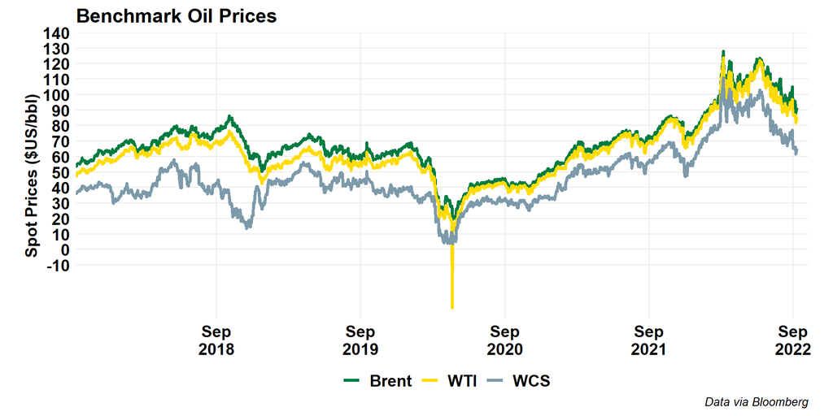

### Alberta Crude

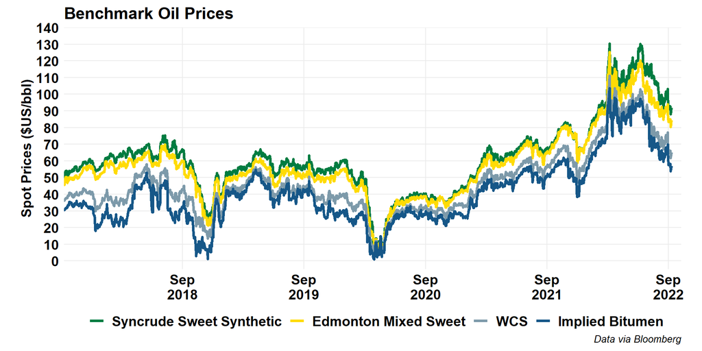

### Alberta Crude (Short)

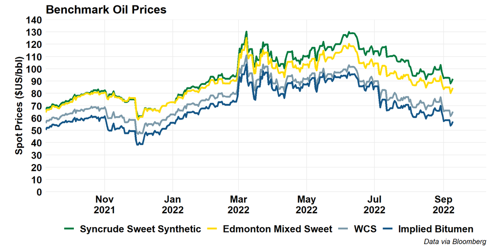

### US Crude

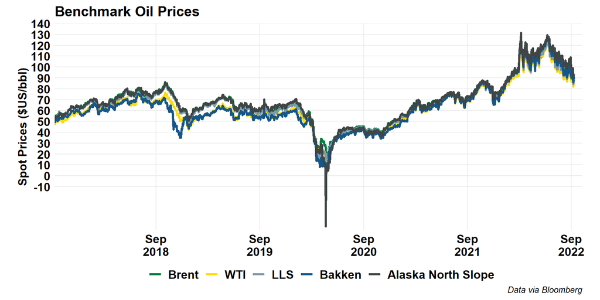

### Global Crude

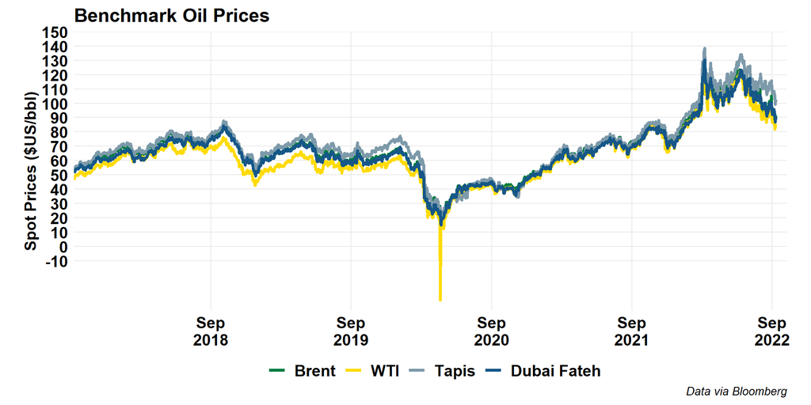

## Oil Price Differentials

### Brent-WTI

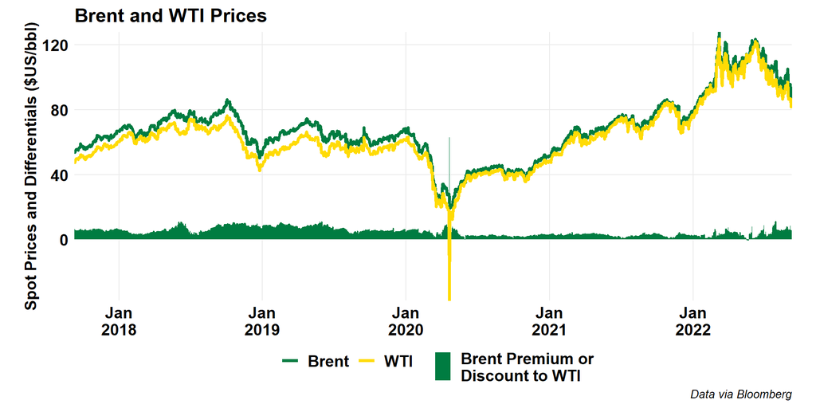

### WTI-WCS

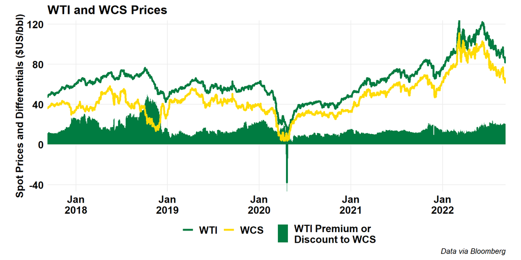

### WTI-WCS (Short)

[figure not shown]

### Maya-WCS

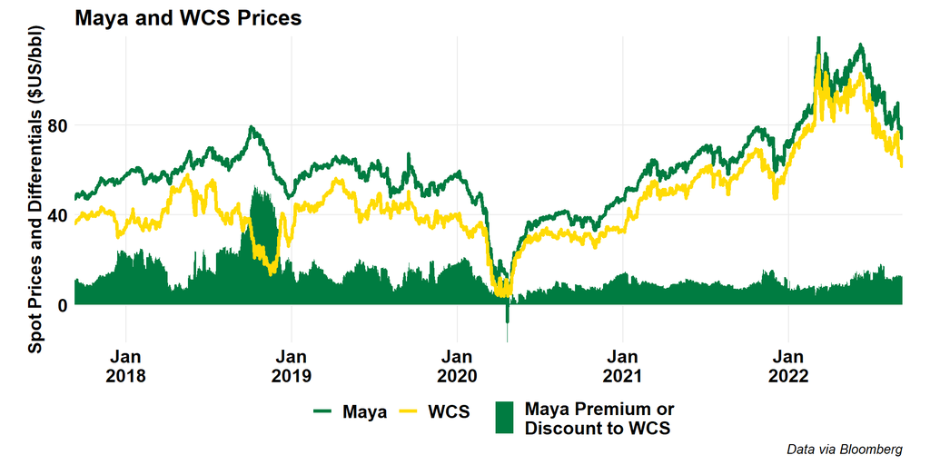

### WTI Cushing vs MEH

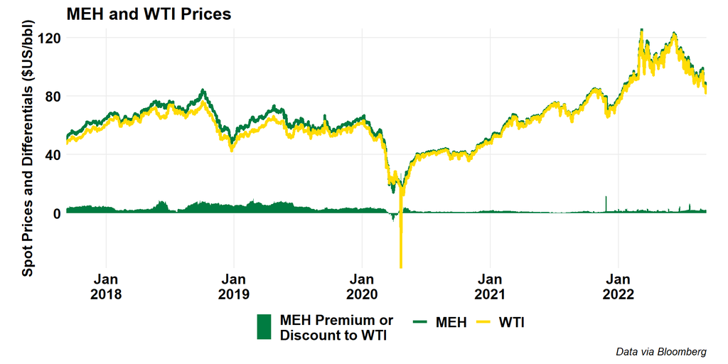

## Forward Curves

### WTI

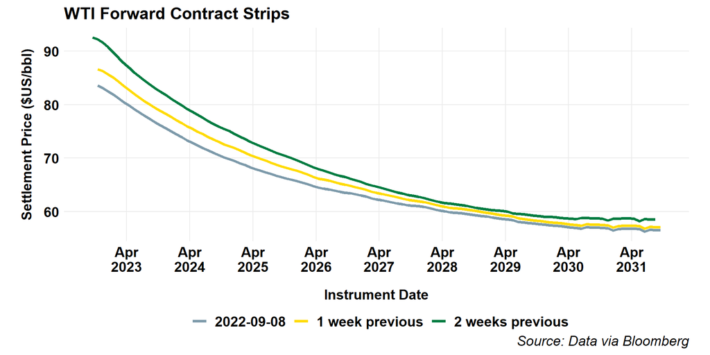

### Brent

[figure not shown]

## Canadian Crude Supply and Disposition

### Production

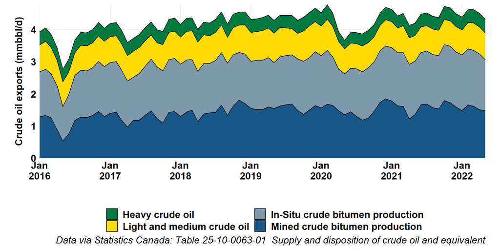

### Imports

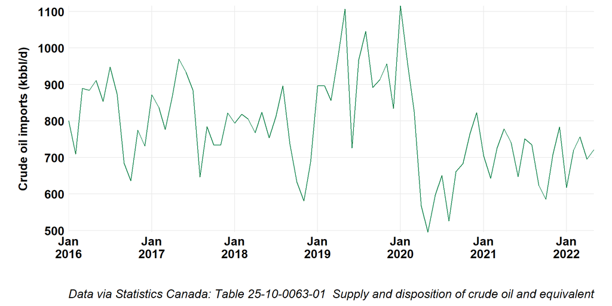

### Exports

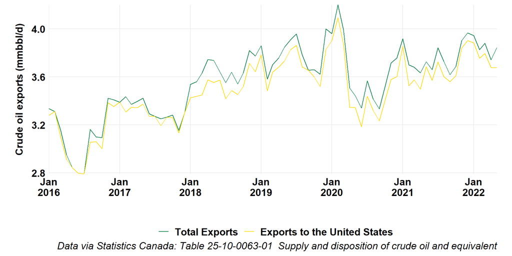

### Rail Exports

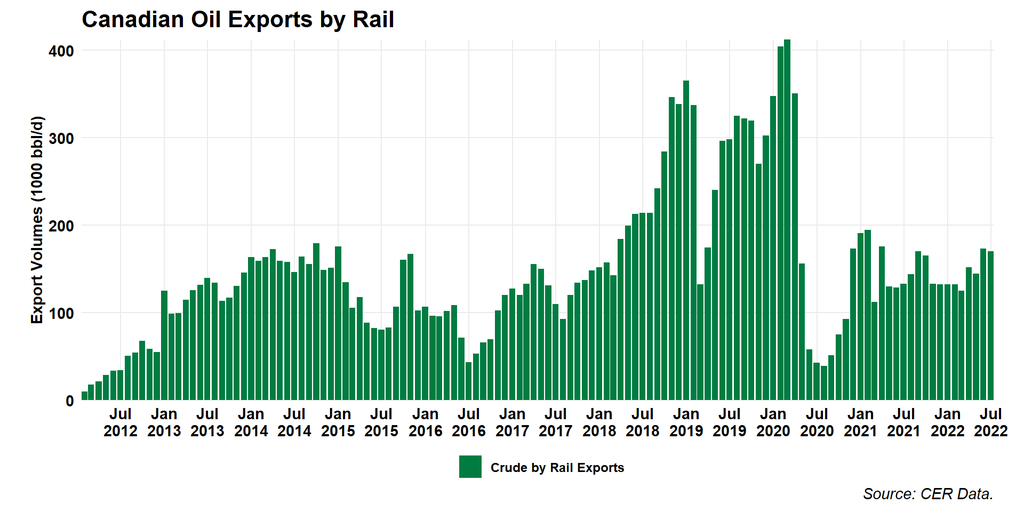

## US Oil

### Production

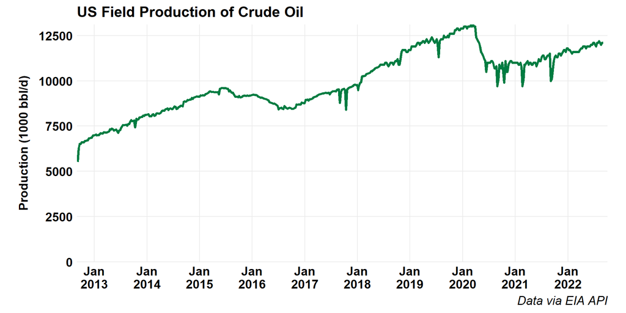

### LTO Production by Play

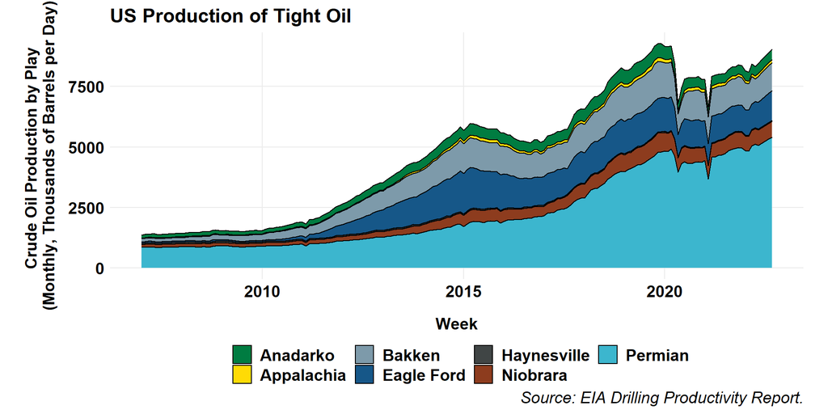

### Net Imports

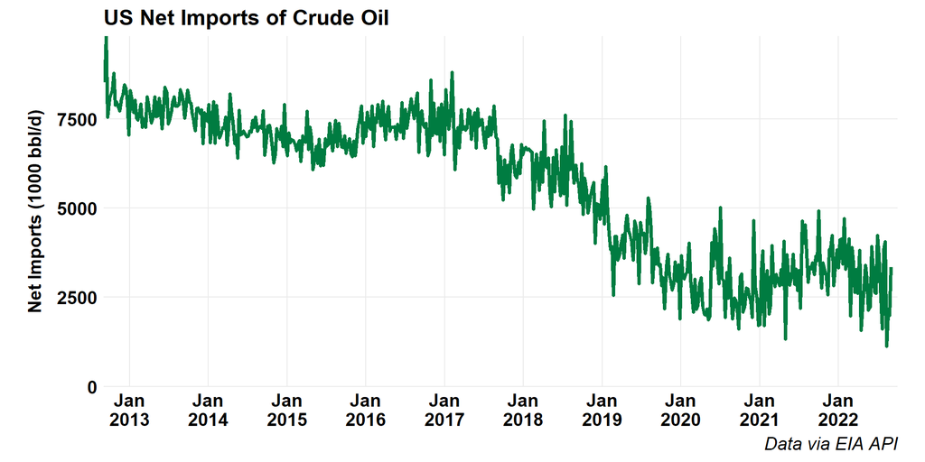

### Oil and Product Net Imports

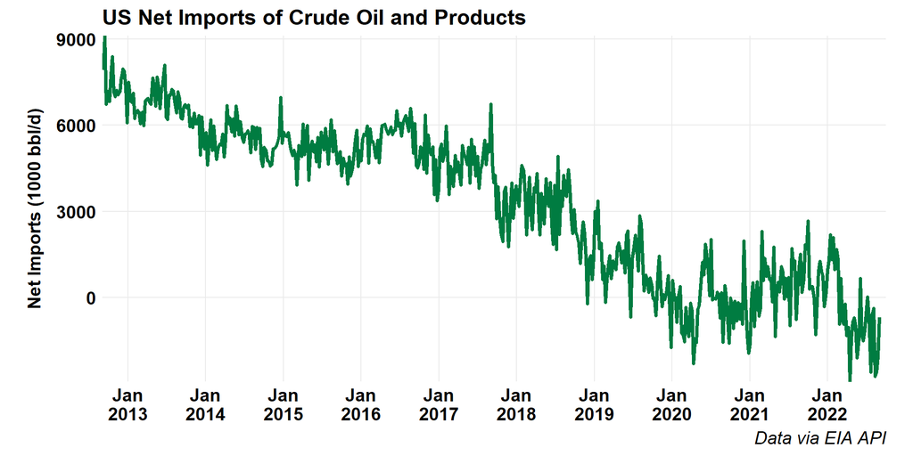

### Inventories

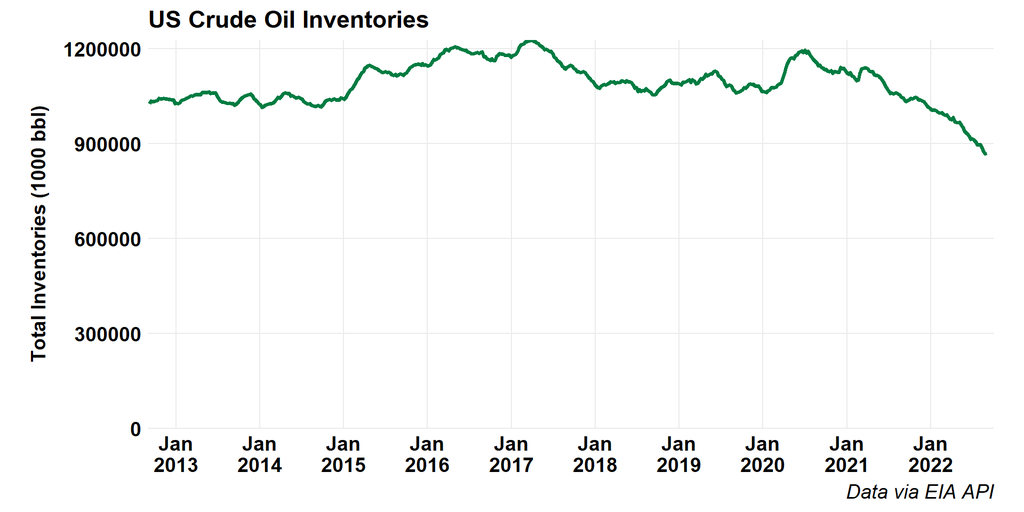

# Refined Products

## Canadian Gasoline Prices

### Map

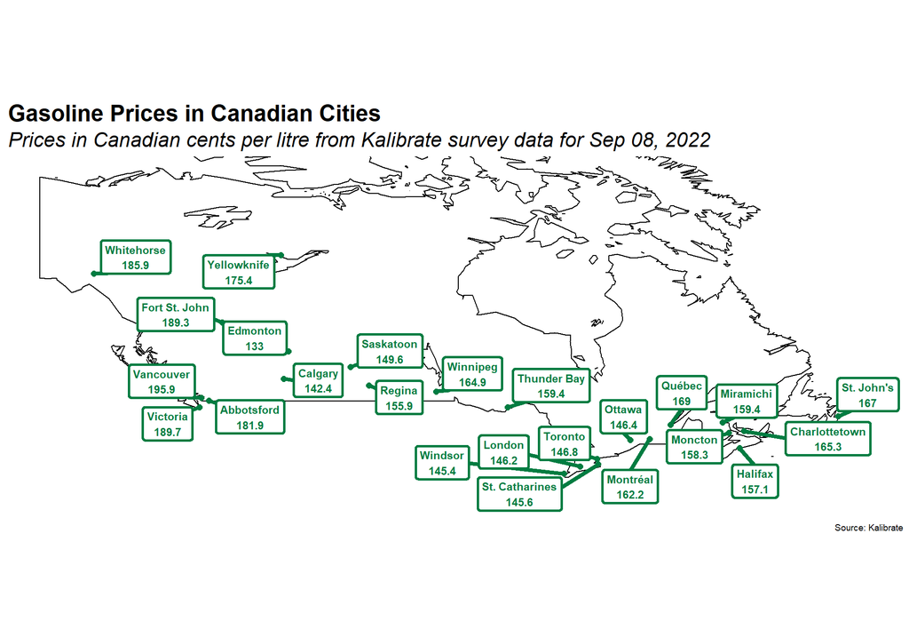

### Historic Gasoline Prices

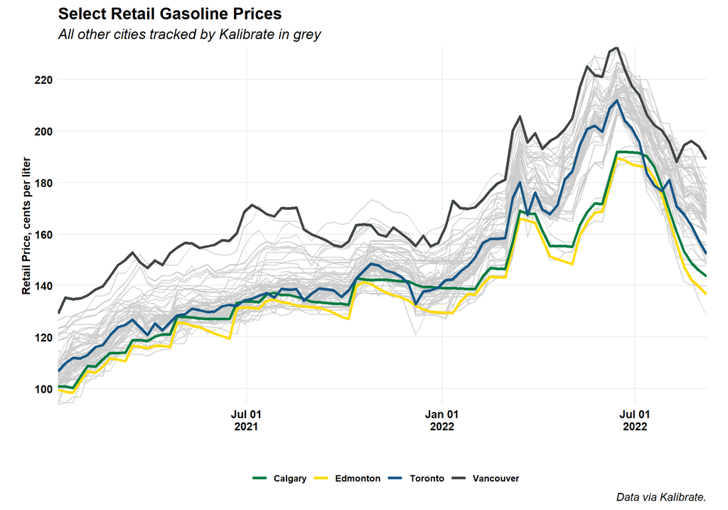

### Historic Gasoline Prices in BTC

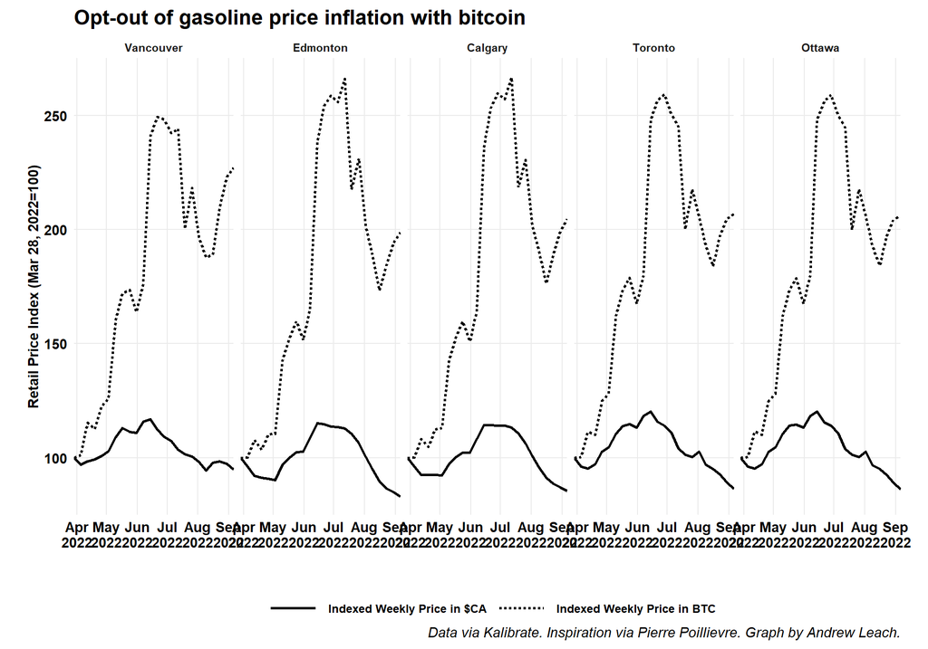

### Historic Diesel Prices

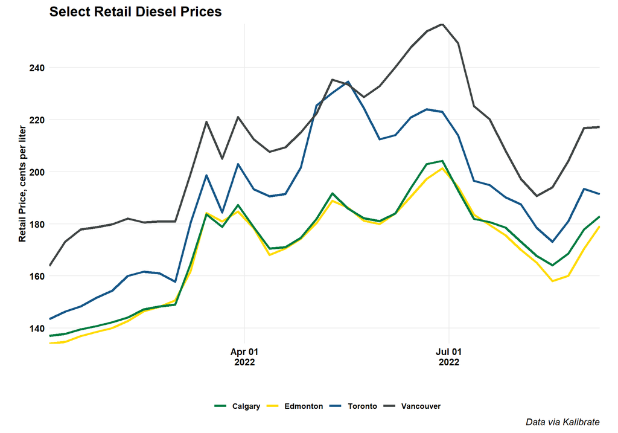

## Canadian Refinery Runs

### Canadian Refinery Runs

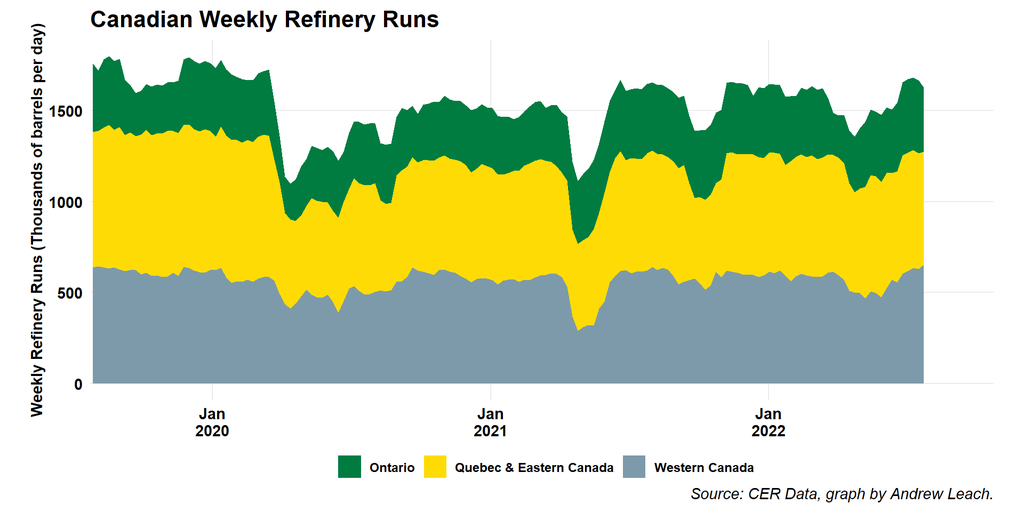

### Western Canada Refinery Runs

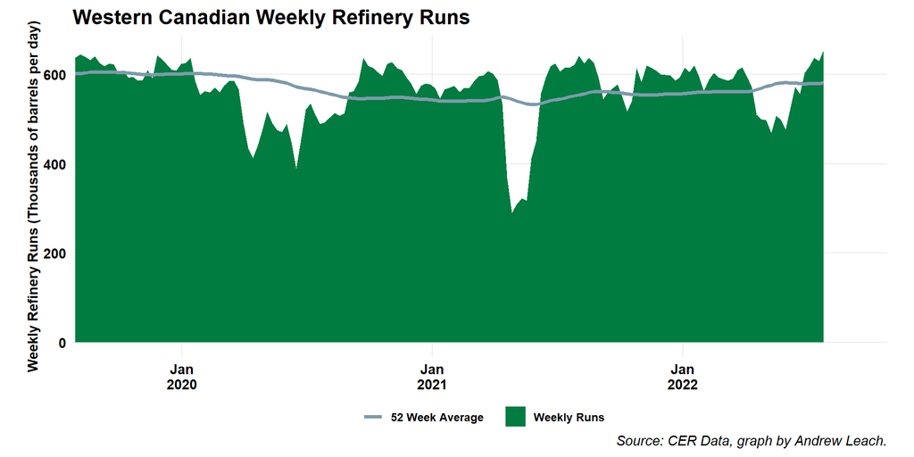

# Natural Gas

## Natural Gas Market Summary

### Feature Gas

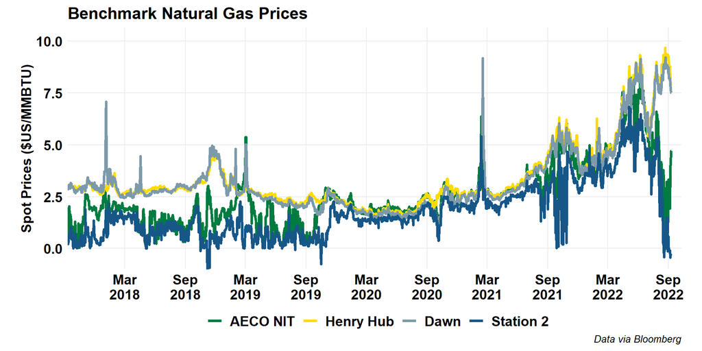

### Feature Gas (Short)

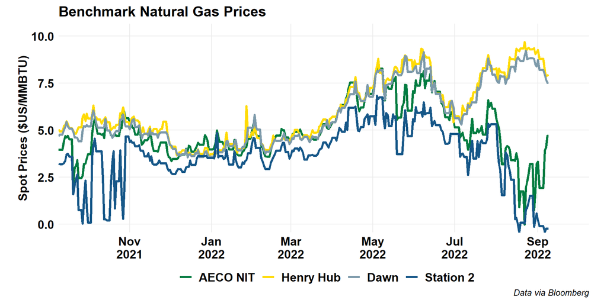

### Global Gas

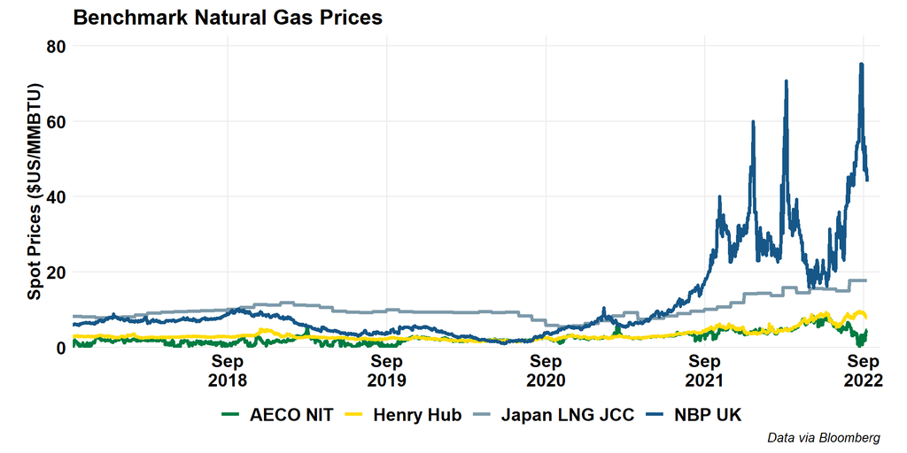